# Cite-seq analyses

Jingxian Li

2021/11/13

## Library packages

```r
# library packages
library(Seurat)
library(plyr)
library(dsb)
library(ComplexHeatmap)
library(RColorBrewer)
library(reticulate)
library(CellChat)
library(patchwork)
library(scater)
source('/fs/ess/PCON0022/jyx/ljxian/HGT/cite/citefunction.R')
```

## Obtain RNA and ADT matrixs

```r
sourcedata <- readRDS('/fs/ess/PCON0022/Xiaoying/cite-seq/casestudy/normal.rds')
rna <-sourcedata@assays$RNA@counts[,which(sourcedata@meta.data$supercluster!='Other')]
adt <-sourcedata@assays$ADT@counts[,which(sourcedata@meta.data$supercluster!='Other')]
```

## Create a seurat object with two matirxs, *RNA* and *ADT*

Since the source of the data has been filtered, we didn’t do filtering here. Two resulting matrixes in the Seurat object (PBMCandLung_obj) obtained from ReadData() function, RNA and ADT have been normalized and scaled, and highly variable genes and proteins have been found. Then we spliced together the ADT matrix and RNA matrix of 2000 highly variable genes and used CLR normalization on the spliced matrix. It was accomplished by function CLR() function, and the result matrix is GAS() function, which is the input to the HGT model.

```r
# Creat a seuart object
# input:
# rna_matrix: a RNA matrix where the rows correspond to genes and the columns correspond to cells. (When dataFormat is 'matrixs', it couldn't be NULL.)
# adt_matrix: a matrix where the rows correspond to proteins and the columns correspond to cells. (When data_type is 'CITE' and dataFormat is 'matrixs', it couldn't be NULL.)
# data_type: the type of your input data, 'CITE' or 'scRNA_scATAC'
# dataFormat: the format of your input data
# min_cell: the peak / gene will be removed if the value in the gene / peak with more than min_cell cell is equal to zero
# nmad: a numeric scalar, specifying the minimum number of MADs away from median required for a value to be called an outlier
# gene.filter: whether do gene filtering or not
# gene.filter: whether do cell filtering or not
# output:
# obj: a seuart object for cite-seq data after normalizing and scaling
PBMCandLung_obj <- ReadData(rna_matrix = rna, adt_matrix = adt, data_type = 'CITE', dataFormat='matrixs', gene.filter=FALSE, cell.filter=FALSE)
# splice togethor the RNA matrix and ADT matrix and do normalization
# input:
# obj: a seuart object obtained from creatobject fuction
# output:
# GAS : the spliced and normalized matrix as the input of HGT model
GAS <- CLR(obj = PBMCandLung_obj)
```

## Run HGT model

Your working directory should contain pyHGT directory and arg.py file which can be obtained from Github; You can choose using conda environment by setting the argument envPath; The variable result_dir is your address to storage cell embedding matrix, feature embedding, and attention information. The directory should contain subdirectories named as ‘cell’, ‘gene’, ‘att’ and ‘model’; Running HGT model on the GAS matrix can be accomplished by function run_HGT; The argument data_type can be set to ‘CITE’, ‘scRNA_scATA’, or ‘multiple RNA’. Here, we use ‘CITE’. More parameters’ introduction can see the file citefunction.R, containing hyperparameters of HGT model (epoch, lr, n_hid, n_head); The results and information you will need in the subsequent analysis are stored in a list HGTresult.

```r
envPath = "/users/PCON0022/yjm85/.conda/envs/HGT"
setwd('/fs/ess/PCON0022/jyx/ljxian/HGT/cite/')
result_dir <- '/fs/ess/PCON0022/jyx/ljxian/HGT/cite'
# Run HGT model
# input:
# GAS: the spliced and normalized matrix obtained from CLR function
# result_dir: The address for storing the models and optimization results(Type:str)
# epoch:(Type:int)
# lr: learning rate(Type:float)
# n_hid: Number of hidden dimension(Type:int)
# n_heads: Number of attention head(Type:int)
# cuda: 0 use GPU0 else cpu(Type:int)
# data_type: 'CITE', 'scRNA_scATAC', or 'multipleRNA'
# envPath: The address for environment to use if use.env is TRUE(Type:str)
# output:
# HGT_result: a list containing requried results of HGT model as follows:
# parameters: given parameters from user --epoch, lr, n_hid, n_heads, cuda
# cell_hgt_matrix: cell embedding matrix
# feature_hgt_matrix : gene embedding matrix and protein embedding matrix when data_type is 'CITE';
# attention: attention meassage for features and cells
# data_type: 'CITE', 'scRNA_scATAC'', or 'multipleRNA'
# result_dir: The address for storing the models and optimization results
# GAS: the spliced and normalized matrix obtained from CLR function
HGTresult <- run_HGT(GAS=GAS, result_dir=result_dir, data_type='CITE', envPath=envPath, lr=0.08, epoch=100, n_hid=128, n_heads=8,cuda=0)
```

## Cluster the cells based on cell embedding matrix generated from HGT model

Cell embedding matrix generated from HGT model (cell_hgt_matrix) can be obtained from HGTresult$cell_hgt_matrix. Please note that different GPU versions will affect the results. The nhid argument is input parameter n_hid of the HGT model which can be viewed in HGTresult$parameters.

```r
cell_hgt_matrix <- HGTresult$cell_hgt_matrix
```

```r
# Cluster cells based on HGT embedding
# input:
# cell_hgt_matrixPath: the path of cell_embedding matrix
# nhid: hyper-parameter of HGT model
# resolution: resolution of cell clustering
# obj: a seurat object obtained from ReadData fuction
# output:
# obj: a seurat object containing cell clustering result
PBMCandLung_obj <- HGT_cluster(obj=PBMCandLung_obj, cell_hgt_matrix=cell_hgt_matrix, nhid = 128, resolution = 2)
```

## Run UMAP reduction

We use all dimensions of HGT embedding as the input to the UMAP.

```r
# Run UMAP reduction and visualize the result
nhid <- 128
PBMCandLung_obj <- RunUMAP(PBMCandLung_obj, reduction = 'HGT', dims = 1:nhid, reduction.name = "umap.hgt", reduction.key = "hgtUMAP_")
```

## Visualize the UMAP result

Here, we use clustering results obtained from HGT_cluster() function as the label to draw dimplot.

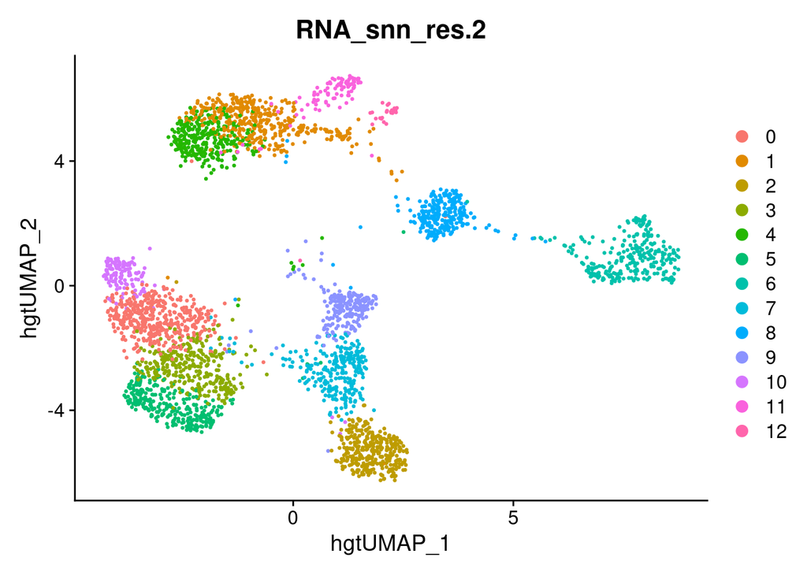

```r
DimPlot(PBMCandLung_obj, reduction = 'umap.hgt', group.by = 'RNA_snn_res.2',repel = TRUE, label.size =3)
```

## Visualizing gene markers’ expression

VlnPlot() (shows expression probability distributions across clusters), and FeaturePlot() (visualizes feature expression on a UMAP plot) are visualizations of markers’ expression.

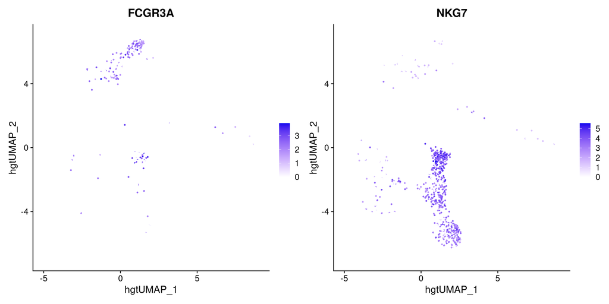

```r
# Visualizing gene markers' expression using tools from Seurat
gene_markers <- c('FCGR3A', 'NKG7')
DefaultAssay(PBMCandLung_obj) <- 'RNA'
FeaturePlot(PBMCandLung_obj,features = gene_markers, reduction = 'umap.hgt',pt.size = 0.5 , cols = c('white','blue2'))
```

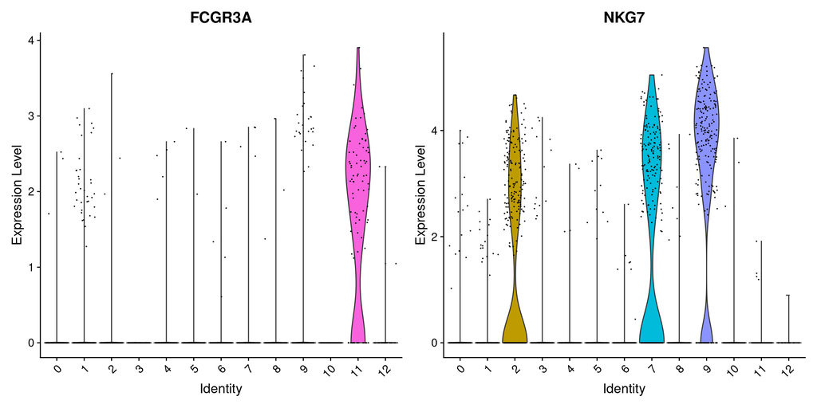

```r
VlnPlot(PBMCandLung_obj, features = gene_markers , group.by = 'RNA_snn_res.2')
```

## Visualizing protein markers’ expression

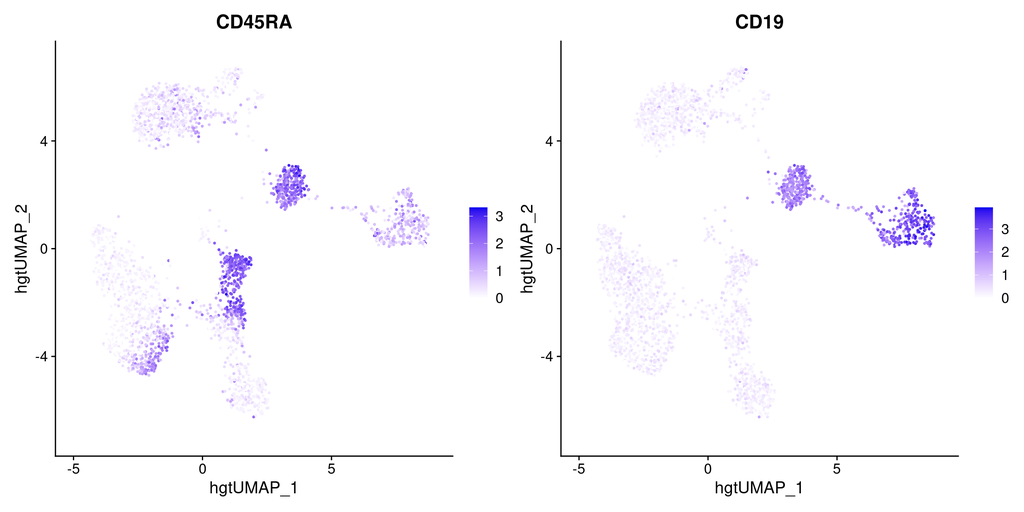

```r
# Visualizing protein markers' expression using tools from Seurat
adt_markers <- c('CD45RA', 'CD19')
DefaultAssay(PBMCandLung_obj) <- 'ADT'
FeaturePlot(PBMCandLung_obj,features = adt_markers, reduction = 'umap.hgt',pt.size = 0.5 , cols = c('white','blue2'))
```

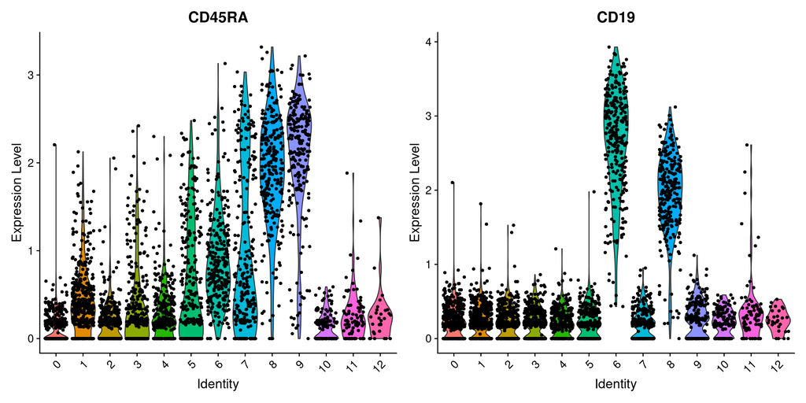

```r
VlnPlot(PBMCandLung_obj, features = adt_markers, group.by = 'RNA_snn_res.2')
```

## Assigning cell type identity to clusters

By observing the visualization results of markers as above, we annotate cell types. Then assign them to the corresponding clusters and set them to identities of the Seurat object.

```r
# Assigning cell type identity to clusters
# library(plyr)
ct <- c('Tregs', 'Monocytes1', 'Tissue resident memory CD8+ T cells', 'Central memory-like CD4+ T cells', 'Monocytes2', 'Naïve CD4+ T cells', 'Plasma cells', 'Central memory-like CD8+ T cells', 'Memory B cells', 'NK cells', 'Tissue resident memory CD4+ T cells', 'Tumor-associated macrophages', 'Dendritic cells')
ct_res.2 <-mapvalues(PBMCandLung_obj@meta.data$RNA_snn_res.2, 0:12 ,ct)
PBMCandLung_obj@meta.data$cell_type <- ct_res.2
Idents(PBMCandLung_obj) <- ct_res.2
```

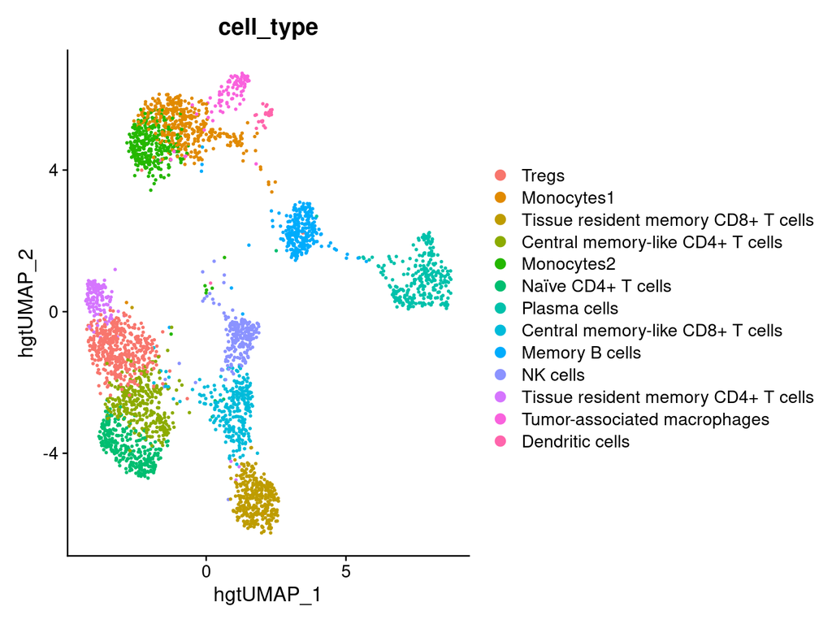

```r
DimPlot(PBMCandLung_obj, reduction = 'umap.hgt', group.by = 'cell_type',repel = TRUE, label.size =3)
```

## Heatmaps of curated marker proteins and genes that determine the cell clustering and annotation

```r
if (!requireNamespace("openxlsx", quietly = TRUE))
  install.packages("openxlsx")
library(openxlsx)
# Set the order of celltypes to display in heatmap
ctorder <- c('Naïve CD4+ T cells','Central memory-like CD4+ T cells','Central memory-like CD8+ T cells','Tissue resident memory CD4+ T cells','Tissue resident memory CD8+ T cells','Tregs','NK cells','Memory B cells','Plasma cells','Monocytes1','Monocytes2','Tumor-associated macrophages','Dendritic cells')
```

```r
# Read character of RNA markers(the order of markers corresponding to ctorder) from file.
RNAmarker <- read.xlsx('/fs/ess/PCON0022/jyx/cite/cs/10292021_Updated_RNA_marker_sequence_heatmap.xlsx',colNames = F)
RNAmarker <- gsub('[.]','-',unlist(RNAmarker))
head(RNAmarker)
```

```
##    X11    X12    X13    X14    X15    X16
## "CD3E"  "CD4" "CD8A" "CCR7" "IL7R" "CD69"
```

```r
# Read character of ADT markers(the order of markers corresponding to ctorder) from file.
ADTmarker <- read.xlsx('/fs/ess/PCON0022/Xiaoying/cite-seq/casestudy/serve/cs2/10272021_ADT_sequence_heatmap_2.0.xlsx',colNames = F)
ADTmarker <- gsub('[.]','-',unlist(ADTmarker))
head(ADTmarker)
```

```
##     X11     X12     X13     X14     X15     X16
## "TCRab"   "CD3"   "CD4" "CD62L" "CD127"   "CD8"
```

```r
# Generates expression heatmaps for curated marker proteins and genes that determine the cell clustering and annotation
# Draw a heatmap of marker genes
# required packages: dsb, ComplexHeatmap
# input:
# obj: a seurat object obtained from HGT_cluster fuction
# marker: character of markers(the order of markers corresponding to ctorder)
# ctorder: the order of celltypes to display
# assays: RNA or ADT
# output:
# a heatmap of marker proteins or genes

# Draw a heatmap of marker genes
RNAMarkerHeatmap<- MarkerHeatmap(obj = PBMCandLung_obj, marker=RNAmarker,ctorder=ctorder,assays='RNA')
# Draw a heatmap of marker proteins
ADTMarkerHeatmap <- MarkerHeatmap(obj = PBMCandLung_obj, marker=ADTmarker,ctorder=ctorder,assays='ADT')
```

### Heatmap of genes that determine the cell clustering and annotation

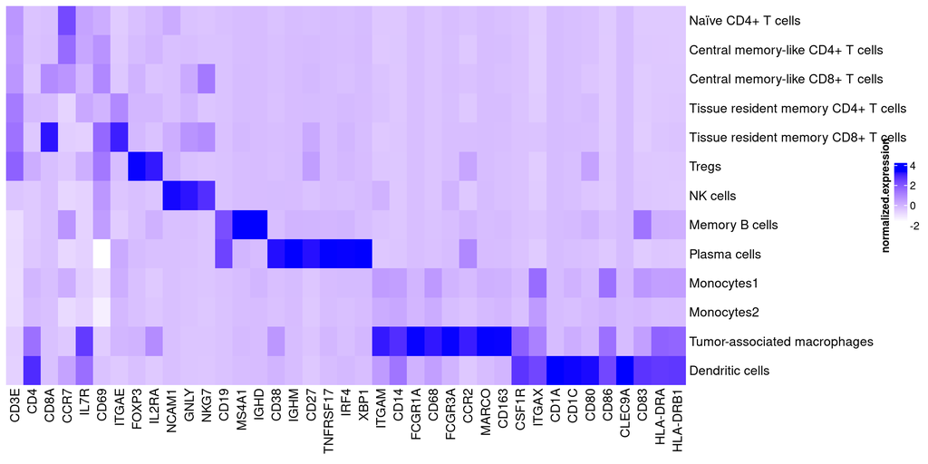

```r
print(RNAMarkerHeatmap)
```

### Heatmap of curated marker proteins that determine the cell clustering and annotation

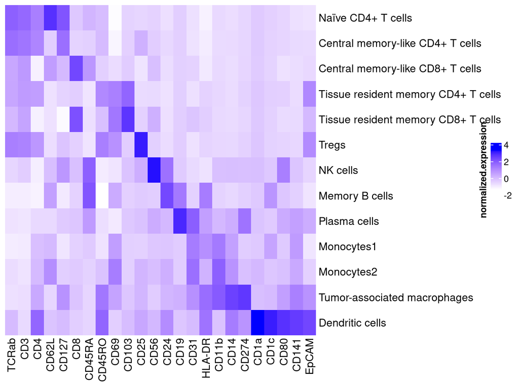

```r
print(ADTMarkerHeatmap)
```

## Draw UMAP colored by a certain dimension of HGT embedding

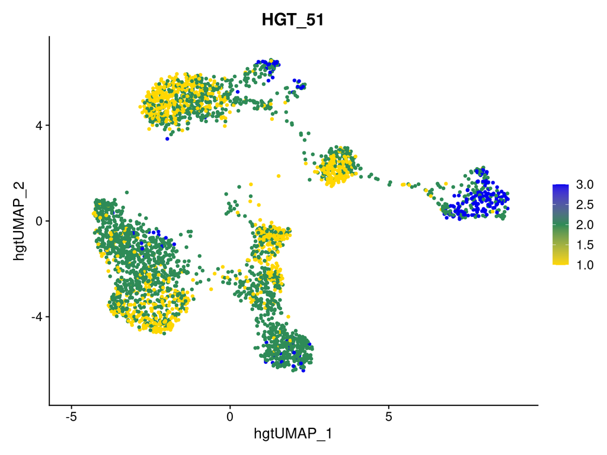

```r
# Draw UMAP colored by HGT_51 embedding
j <- 51
FeaturePlot(PBMCandLung_obj,paste0('HGT_',j), reduction = 'umap.hgt',pt.size = 1 , cols = c('gold','seagreen','blue2'))
```

## Draw heatmap and loess smoothing plot for two cell types

We found top differentially expressed genes, proteins, and their associated features for two cell types. We used their Pearson correlation coefficients to draw a heatmap. The features are labeled by different colors which represent cell types(color1 for ident.1, color2 for ident.2) on the left side of the heatmap plot; Then, we plotted the scaled expression of each feature as a function of HGT_51. For each feature, we smoothed it with a loess curve and colored it by its corresponding cell type label.

```r
# Found top differentially expressed genes, proteins and their associated features for two cell types
ident.1 <- 'Plasma cells'
ident.2 <- 'Memory B cells'
color1 <- '#00C1AB'
color2 <- '#00ACFC'
# Calculate subset of obj under two cell types, the DE features and top associated features
# input:
# obj: a seurat object obtained from HGT_cluster fuction
# ident.1, ident.2: two cell types
# output:
# obj_co: a list of the subset of obj and selected features
obj_co <- subobjco(obj=PBMCandLung_obj, ident.1=ident.1, ident.2=ident.2)
```

### Heatmap for Pearson correlation coefficients between features

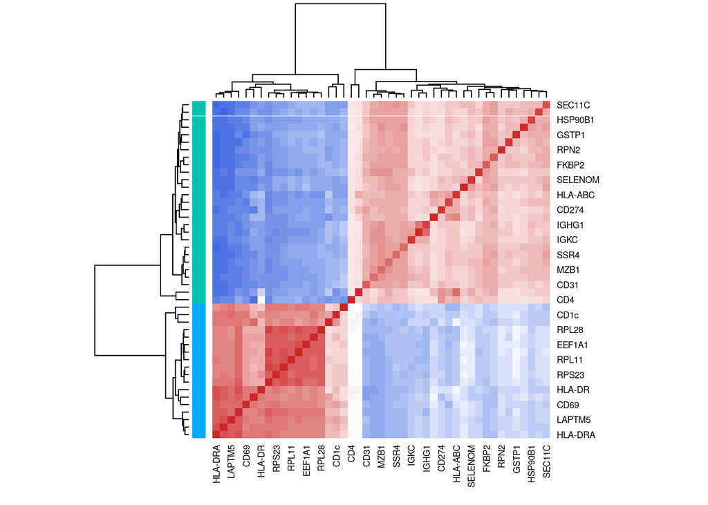

```r
# Draw heatmap on correlation matrix between selected features
# input:
# obj_co: a list obtained from subbmco function
# output:
# heatmap: heatmap on correlation matrix between selected features
fheatmap <- DEfeaturesheatmap(obj_co = obj_co)
```

### Loess smoothing plot

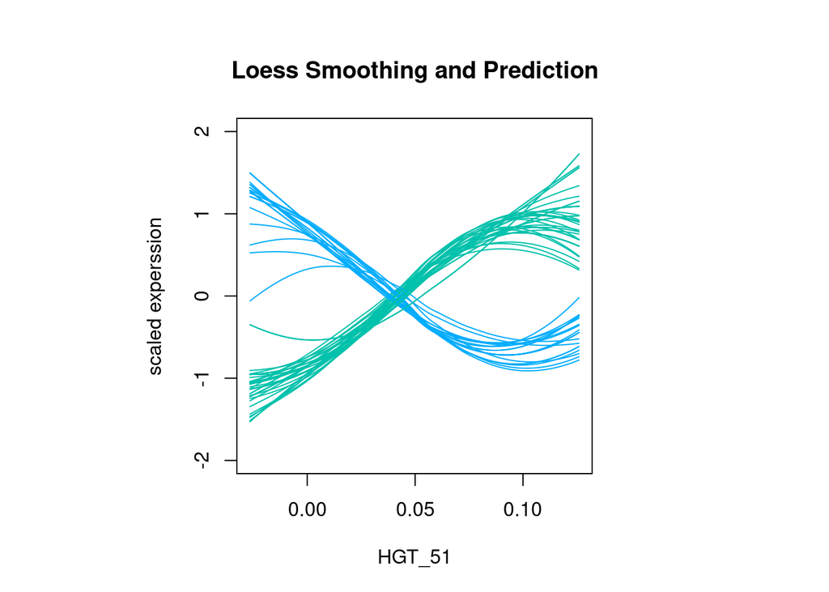

```r
# Draw the lines by a loess smoothing function based on the HGT_51 embedding and scaled gene expressions in two type of cells
# input:
# obj: a seurat object obtained from HGT_cluster fuction
# obj_co: a list obtained from subbmco function
# HGT.dim: a dimension of HGT embedding
# color1, color2: two colors coressponding to two cell types
# output:
# a plot show the relationship between HGT embedding and feature expression
floess <- DEfeaturesloess(obj = PBMCandLung_obj, obj_co = obj_co, HGT.dim = 51, color1 = color1, color2 = color2)
```

## Cell-cell communication analysis by using Cellchat

```r
# cell-cell communication analysis by using cellchat
# input:
# counts matrix of RNA
# celltype annotation on clusters from Deepmaps

options(stringsAsFactors = FALSE)

data.input <- as.matrix(PBMCandLung_obj@assays$RNA@data)
meta <- PBMCandLung_obj@meta.data
cellchat <- createCellChat(object = data.input, meta = meta, group.by = "cell_type")
cellchat <- addMeta(cellchat, meta = meta)
cellchat <- setIdent(cellchat, ident.use = "cell_type")
CellChatDB <- CellChatDB.human
CellChatDB.use <- CellChatDB
cellchat@DB <- CellChatDB.use
cellchat <- subsetData(cellchat)
cellchat <- identifyOverExpressedGenes(cellchat)
cellchat <- identifyOverExpressedInteractions(cellchat)
cellchat <- projectData(cellchat, PPI.human)
cellchat <- computeCommunProb(cellchat)
cellchat <- computeCommunProbPathway(cellchat)
cellchat <- aggregateNet(cellchat)
```

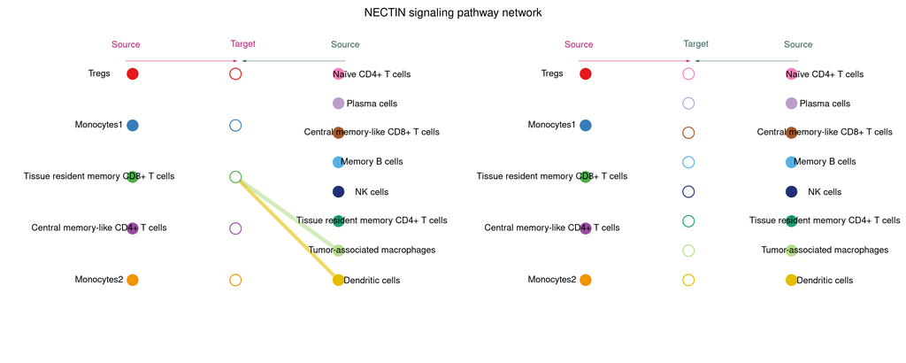

```r
vertex.receiver <- 1:5
pathways.show <- 'NECTIN'
pathwaplot <- netVisual_aggregate(cellchat, signaling = pathways.show,  vertex.receiver = vertex.receiver, pt.title = 18,title.space=2,  layout = 'hierarchy')
```